# ***Predicting Customer Churn with CART Decision Trees ***

**By Sean Kim**

**Activity Overview:**

Now that you have an understanding of CART models, we will build one to predict whether a customer will churn (stop using the service or product).

Telco is a telecommunication services provider. As a marketer for Telco, you are tasked to find out why customers stop using your services and come up with a plan to tackle the problem.

To do this, we will be using a free dataset available on Kaggle called the [Telco Customer Churn](https://www.kaggle.com/datasets/blastchar/telco-customer-churn). This dataset includes variables like, **'gender'**, **'age'**, **'contract type'**, **'monthly charges'**, and many more.

**Learning Outcomes:**

Through this activity, you will explore how a data scientist solves real-world problems. You will go beyond simply building a CART decision tree and learn how it integrates into the broader data science proccess, including data preparation, model training, evaluation, and interpretation.

Expect to learn how to:

1. Load data
2. Perform Exploratory Data Analysis (EDA)
3. Clean and Preprocess Data
4. Defining the Target and Selecting Predictive Features
5. Splitting the data
6. Building a Baseline CART Decision Tree
7. Tuning Hyperparameters
8. Evaluating the Model
9. Analyzing Feature Important
10. Interpreting and Communicating Results (Visualizing)

## **Step 1: Loading data**

First let's load the dataset onto this Google Colab file. Download the [Telco dataset from Kaggle](https://www.kaggle.com/datasets/blastchar/telco-customer-churn) here.

If you have not made an account yet, it's free! You'll gain access to over 50,000 datasets you can practice with.

```python
# Run this cell and choose the dataset from where you saved it.
from google.colab import files
uploaded = files.upload()
```

Upload widget is only available when the cell has been executed in the current browser session. Please rerun this cell to enable.

```
Saving TelcoChurnPrediction.csv to TelcoChurnPrediction.csv
```

```python
import pandas as pd
data = pd.read_csv("TelcoChurnPrediction.csv")
print("Dataset loaded successfully")
```

```
Dataset loaded successfully
```

## **Step 2: Exploratory Data Analysis (EDA)**

**What is EDA?**

Exploratory data analysis (EDA) is the process of examining and summariznig a dataset to understand its main characteristics. By using statistical graphics and other visualization methods, EDA helps us:

- **Understand data distribution:** Identify the shape (normal, skewed, etc.) of numeric variables.
- **Detect outliers:** Find values that differ signicantly from the rest
- **Identify missing data:** Check for null or missing values
- **Uncover Relationships:** Visualize potential relationships between variables (using scatter plots, correlation matrices)

**What are we looking for?**

In our case of predicting churn rate we're looking for:

- The overal structure and types of data available
- The distribution of key numeric variables like **'MonthlyCharges'**, **'tenure'**, and **'TotalCharges'**
- How features might relate to customer churn (**'Churn'** vs. **'tenure'**)
- Whether there are outliers or anomalies

```python
# Import necessary tools
import matplotlib.pyplot as plt
import seaborn as sns


# Basic informaion of data
print("Dataset Overview:")
print(data.info())
print("First 5 rows:")
print(data.head())
```

```
Dataset Overview:
<class 'pandas.core.frame.DataFrame'>
RangeIndex: 7043 entries, 0 to 7042
Data columns (total 21 columns):
 #   Column            Non-Null Count  Dtype
---  ------            --------------  -----
 0   customerID        7043 non-null   object
 1   gender            7043 non-null   object
 2   SeniorCitizen     7043 non-null   int64
 3   Partner           7043 non-null   object
 4   Dependents        7043 non-null   object
 5   tenure            7043 non-null   int64
 6   PhoneService      7043 non-null   object
 7   MultipleLines     7043 non-null   object
 8   InternetService   7043 non-null   object
```

[output cut: 45 more lines]

```python
# Summary Statistics
print("Summary Statistics")
print(data.describe())
```

```
Summary Statistics
       SeniorCitizen       tenure  MonthlyCharges
count    7043.000000  7043.000000     7043.000000
mean        0.162147    32.371149       64.761692
std         0.368612    24.559481       30.090047
min         0.000000     0.000000       18.250000
25%         0.000000     9.000000       35.500000
50%         0.000000    29.000000       70.350000
75%         0.000000    55.000000       89.850000
max         1.000000    72.000000      118.750000
```

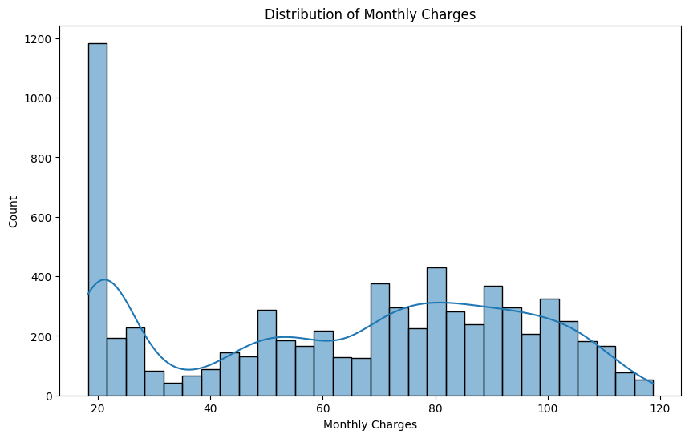

```python
# Visualizing the distribution of 'MonthlyCharges'
plt.figure(figsize = (10,6))
sns.histplot(data['MonthlyCharges'], bins = 30, kde = True)
plt.title("Distribution of Monthly Charges")
plt.xlabel("Monthly Charges")
plt.show()
```

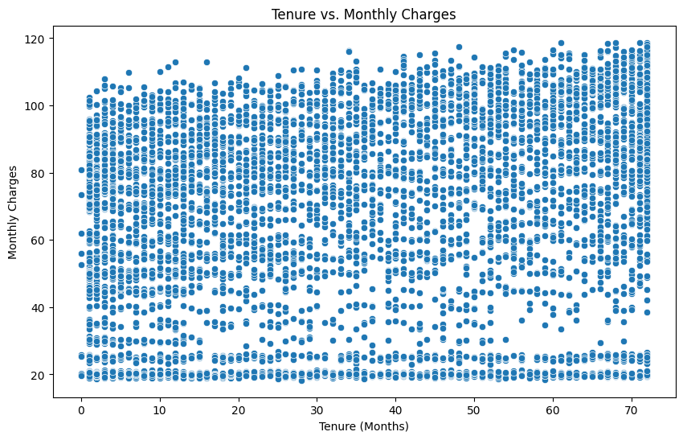

```python
# Scatter plot: 'Tenure' vs. 'MonthlyCharges'
plt.figure(figsize = (10, 6))
sns.scatterplot(x = 'tenure', y = 'MonthlyCharges', data = data)
plt.title("Tenure vs. Monthly Charges")
plt.xlabel("Tenure (Months)")
plt.ylabel("Monthly Charges")
plt.show()
```

**What can we say about the relationships?**

Feel free to modify the code to look compare other features in the dataset. See if you can find features and relationships

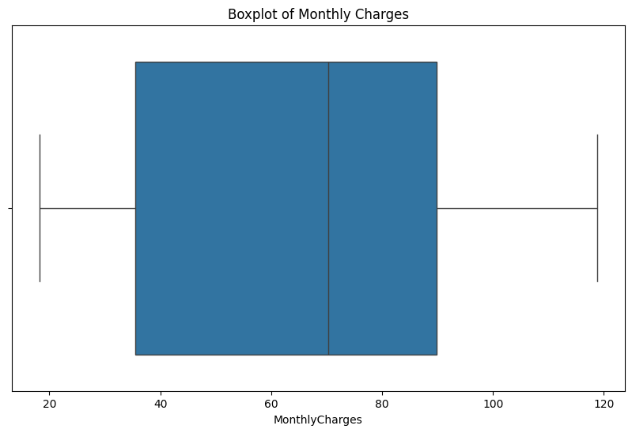

```python
plt.figure(figsize = (10, 6))
sns.boxplot(x = data ['MonthlyCharges'])
plt.title("Boxplot of Monthly Charges")
plt.show()
```

## **Step 3: Data Cleaning and Preprocessing**

Now that we know what our data looks like, we need to ensure that it is ready for modeling.

The first thing we will do is to handle missing values by getting rid of any rows with missing data.

```python
# Handling Missing Values
data = data.dropna()
```

For the dataset we are using, we have 17 features that are categorical, meaning they aren't numbers that an algorithm can understand.

We need to convert them into numerical values that our CART decision tree algorithm can understand. There are multiple ways we can do this.

```python
# Method 1: Converting 'gender' and 'Churn' into numerical variables:
data['gender'] = data['gender'].map({'Male':0, 'Female':1})
data['Churn'] = data['Churn'].map({'Yes':1, 'No':0})
```

Seems like tedious work, so here's a faster way to do it.

```python
# Method 2: Convert the others

categorical_columns = ['customerID', 'Partner', 'Dependents', 'PhoneService',
                       'MultipleLines', 'InternetService', 'OnlineSecurity',
                       'OnlineBackup', 'DeviceProtection', 'TechSupport',
                       'StreamingTV', 'StreamingMovies', 'Contract',
                       'PaperlessBilling', 'PaymentMethod']

for col in categorical_columns:
  data[col] = data[col].astype('category').cat.codes
```

```python
print(data.dtypes)
```

```
customerID            int16
gender                int64
SeniorCitizen         int64
Partner                int8
Dependents             int8
tenure                int64
PhoneService           int8
MultipleLines          int8
InternetService        int8
OnlineSecurity         int8
OnlineBackup           int8
DeviceProtection       int8
TechSupport            int8
StreamingTV            int8
StreamingMovies        int8
Contract               int8
PaperlessBilling       int8
PaymentMethod          int8
MonthlyCharges      float64
TotalCharges         object
Churn                 int64
dtype: object
```

**Hold on, why is it an object?**

'TotalCharges' seems to be an object, but when we take a look at the values in the column, they look like integers or floats.

```python
# Let's fix that

import numpy as np
# Removing whitespace
data['TotalCharges'] = data['TotalCharges'].str.strip()

# Replace empty strings wth NaN
data['TotalCharges'] = data['TotalCharges'].replace('', np.nan)

# Convert to float
data['TotalCharges'] = data['TotalCharges'].astype(float)


# Method 2
# data['TotalCharges'] = pd.to_numeric(data['TotalCharges'], errors='coerce')


# Checking again
print(data.dtypes)
```

```
customerID            int16
gender                int64
SeniorCitizen         int64
Partner                int8
Dependents             int8
tenure                int64
PhoneService           int8
MultipleLines          int8
InternetService        int8
OnlineSecurity         int8
OnlineBackup           int8
DeviceProtection       int8
TechSupport            int8
StreamingTV            int8
StreamingMovies        int8
Contract               int8
PaperlessBilling       int8
PaymentMethod          int8
MonthlyCharges      float64
TotalCharges        float64
Churn                 int64
dtype: object
```

## **Step 4: Creating the Target Variable and Selecting Features**

**Why set the Target Variable?**

In supervised learning, the target variable is what we want the model to predict.

Sometimes the dataset includes the target variable we want predict, other times we might want to create a new one.

We will be setting **'Churn'** (1 for churned customers, 0 for those who stayed)as our target variable.

**Selecting Predictors**

For our model, we will use all available features for our predictors *except* for our target variable and in the case that we created a target variable—any additional features used for the target variable.

```python
# Creating a list of predictors by excluding the target feature ('Churn')
all_predictors = list(data.columns)
all_predictors.remove('Churn')

# Creating matrix of features (X) and target feature (y)
X = data[all_predictors]
y = data['Churn']

# Take a look at the predictors we have selected
print("The selected predictors:", all_predictors)
```

```
The selected predictors: ['customerID', 'gender', 'SeniorCitizen', 'Partner', 'Dependents', 'tenure', 'PhoneService', 'MultipleLines', 'InternetService', 'OnlineSecurity', 'OnlineBackup', 'DeviceProtection', 'TechSupport', 'StreamingTV', 'StreamingMovies', 'Contract', 'PaperlessBilling', 'PaymentMet…
```

**Take a look at the predictors here. Think about them. Does it make sense to include all of them?**

**Learn more**

- If you recall from your reading, decision trees naturally select the most informative features (we will see how this works in a bit).
- Even if you believe a feature may not have any effect on the prediction, you never know what the model might uncover. It makes more sense to include all the features for the model to work its magic.

## **Step 5: Splitting the Data into Training and Testing Sets**

**Why split your data?**

Splitting your data into training and test sets is crucial to building a strong machine learning model.

A common split is to use 70% of the data for trainingg and the remaining 30% for testing.

A 70/30 split helps balance between having enough data to train the model while reserving enough data to test the model. Too little training data might lead to a model that doesn't capture the true patterns, while too little testing data might not adequately reflect the model's predictions on new data.

```python
# importing necessary tools
from sklearn.model_selection import train_test_split

X_train, X_test, y_train, y_test = train_test_split(X, y, test_size = 0.3, random_state = 707)

# Verify the sizes of your splits
print("Training set shape:", X_train.shape)
print("Test set shape:", X_test.shape)
```

```
Training set shape: (4930, 20)
Test set shape: (2113, 20)
```

## **Step 6: Building a CART Decision Tree Model**

Now that we have finished preparing our data, let's build the decision tree. For our model, we will be using scikit‑learn’s 'DecisionTreeClassifier'.

Since our target variable 'Churn' is binary, this is a classification problem—we are predicting discrete categories (Churn vs No Churn). If we are dealing with a classification problem, which criterion should we use to guide our decision tree splits?

**Answer**

Gini Impurity or entropy!

While CART decision trees use gini impurity by default, many implementations like scikit-learn allow you to choose entropy as the splitting criterion.

```python
# importing necessary tools
from sklearn.tree import DecisionTreeClassifier, plot_tree, export_text
from sklearn.metrics import accuracy_score, precision_score, recall_score, f1_score, classification_report

# Building and training a CART decision tree
clf = DecisionTreeClassifier(criterion = 'gini', max_depth = 4, random_state = 707)
clf.fit(X_train, y_train)

# Making predictions on the test set
y_pred = clf.predict(X_test)

# Calculating evaluation metrics
baseline_accuracy = accuracy_score(y_test, y_pred)
baseline_precision = precision_score(y_test, y_pred)
baseline_recall = recall_score(y_test, y_pred)
baseline_f1 = f1_score(y_test, y_pred)
baseline_classification_report = classification_report(y_test, y_pred)

print("Baseline Accuracy:", baseline_accuracy)
print("Baseline Precision:", baseline_precision)
print("Baseline Recall:", baseline_recall)
print("Baseline F1:", baseline_f1)
print("Baseline Classification Report:")
print(baseline_classification_report)
```

```
Baseline Accuracy: 0.7714150496923805
Baseline Precision: 0.6762820512820513
Baseline Recall: 0.35581787521079256
Baseline F1: 0.4662983425414365
Baseline Classification Report:
              precision    recall  f1-score   support

           0       0.79      0.93      0.85      1520
           1       0.68      0.36      0.47       593

    accuracy                           0.77      2113
   macro avg       0.73      0.64      0.66      2113
weighted avg       0.76      0.77      0.75      2113
```

**Evaluation Metrics Explained**

- Accuracy: This metric represents the proportion of total predictions that are correct. It is calculated as (True Positives + True Negatives) divided by the total number of samples. Accuracy gives a general idea of the model’s overall performance.
- Precision: Precision is the ratio of true positive predictions to all predicted positive instances. In other words, it tells you how reliable the model’s positive predictions are, calculated as TP / (TP + FP).
- Recall (Sensitivity): Recall measures the proportion of actual positive cases that the model correctly identifies. It is calculated as TP / (TP + FN) and is especially important when missing a positive case is costly.
- F1 Score: The F1 score is the harmonic mean of precision and recall. It balances both metrics, providing a single measure of performance that is particularly useful when you need to account for both false positives and false negatives.

**Let's take a look at the significance of each feature at this baseline model**

```python
# Viewing feature importances for the baseline model
baseline_importances = clf.feature_importances_
for feature, score in zip(all_predictors, baseline_importances):
  print(f"Feature: {feature}, Importance: {score:.4f}")
```

```
Feature: customerID, Importance: 0.0023
Feature: gender, Importance: 0.0000
Feature: SeniorCitizen, Importance: 0.0000
Feature: Partner, Importance: 0.0000
Feature: Dependents, Importance: 0.0000
Feature: tenure, Importance: 0.1331
Feature: PhoneService, Importance: 0.0000
Feature: MultipleLines, Importance: 0.0000
Feature: InternetService, Importance: 0.1130
Feature: OnlineSecurity, Importance: 0.1467
Feature: OnlineBackup, Importance: 0.0000
Feature: DeviceProtection, Importance: 0.0000
Feature: TechSupport, Importance: 0.0152
Feature: StreamingTV, Importance: 0.0000
Feature: StreamingMovies, Importance: 0.0000
Feature: Contract, Importance: 0.5661
Feature: PaperlessBilling, Importance: 0.0000
Feature: PaymentMethod, Importance: 0.0000
Feature: MonthlyCharges, Importance: 0.0202
Feature: TotalCharges, Importance: 0.0033
```

Let's make it easier to visually understand the significance of each feature by plotting it.

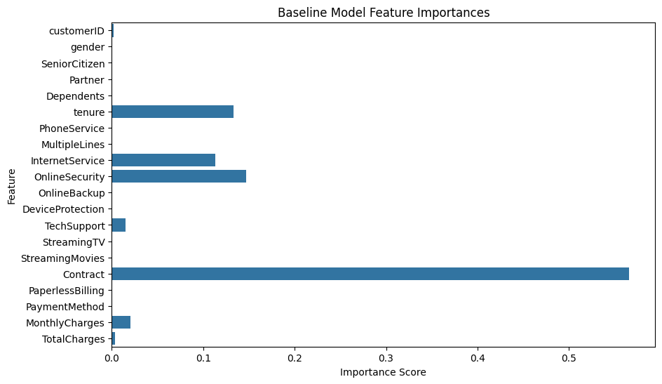

```python
plt.figure(figsize = (10, 6))
sns.barplot(x = baseline_importances, y = all_predictors)
plt.title("Baseline Model Feature Importances")
plt.xlabel("Importance Score")
plt.ylabel("Feature")
plt.show()
```

**What do we think?**

Did you expect these results?

## **Step 7: Hyperparameter Tuning**

**Why and how does hyperparameter tuning improve our model?**

Tuning hyperparameters is essential when the default model settings may not be optimal for the dataset we are using. By tuning the hyperparameters of the CART decision tree (i.e., max_depth, min_samples_split, and min_samples_leaf) we can control the complexity of the tree to best fit the data.

For our activity, we will do this by creating a grid (GridSearchCV) of different values of the hyperparameters to test. GridSearchCV tests these different hyperparameters using a technique called cross-validation.

Cross-validation assesses model performance by splitting the data into multiple training and validation sets.

The most common method is the k-fold cross validation. This method divides the dataset into *k* equally sized 'folds'(parts). For each iteration, one fold is used as the validation set while the remaining *k-1* folds are used for training. This process is repeated *k* times, and the performance metric for each iteration is averaged.

```python
# Importing the necessary tools

from sklearn.model_selection import GridSearchCV

# Define a grid of hyperparameters to search over
param_grid = {
    'max_depth': [3, 4, 5, 6, 7],
    'min_samples_split': [2, 3, 10, 20, 30],
    'min_samples_leaf': [3, 4, 5],
    'criterion': ['gini', 'entropy']
}

# Set up the grid search with cross-validation
# cv = 5 means we will be splitting the data into 5 equal parts
grid_search = GridSearchCV(DecisionTreeClassifier(random_state = 707), param_grid,
                           cv = 5, scoring = 'accuracy')
grid_search.fit(X_train, y_train)

print("Best Hyperparameters:", grid_search.best_params_)

# Build the model using the best parameters found
tuned_clf = grid_search.best_estimator_
y_tuned_pred = tuned_clf.predict(X_test)
tuned_accuracy = accuracy_score(y_test, y_tuned_pred)
print("Tuned Test Set Accuracy", tuned_accuracy)
```

```
Best Hyperparameters: {'criterion': 'entropy', 'max_depth': 5, 'min_samples_leaf': 3, 'min_samples_split': 2}
Tuned Test Set Accuracy 0.7785139611926172
```

**Interpreting the results**

- **Criterion = 'entropy':** The model is using information gain to decide splits. Entropy measures uncertainty; a split that reduces uncertainty significantly is chosen.
- **Max Depth = 5:** The tree can grow up to 5 levels deep, allowing for a moderately complex model that captures more nuanced patterns.
- **Min Samples Split = 2:** A node is eligible to be split if it contains at least 2 samples. This is the smallest valid value.
- **Min Samples Leaf = 3:** After a split, each leaf must contain at least 3 samples. This prevents the model from creating splits that lead to very small, unstable groups.
- **Tuned Accuracy ≈ 77.85%:** This indicates that the tuned model is able to correctly predict churn for roughly 78% of the test cases, an improvement over the baseline.

**Try different hyperparameters**

Modify the grid with different or additional values to see if you can improve the model's performance.

## **Step 8: Evaluating the Tuned Model**

```python
# import the necessary tools
from sklearn.metrics import classification_report

# Print the evaluation metrics for the tuned model
print("Classification Report for Tuned Model:")
print(classification_report(y_test, y_tuned_pred))
```

```
Classification Report for Tuned Model:
              precision    recall  f1-score   support

           0       0.82      0.89      0.85      1520
           1       0.64      0.48      0.55       593

    accuracy                           0.78      2113
   macro avg       0.73      0.69      0.70      2113
weighted avg       0.77      0.78      0.77      2113
```

**What improvements do you see?**

**Analysis of tuned model**

- **Class 0 (No Churn):**
  - **Precision:** Increased slightly to 0.82 from 0.79 (baseline).
  - **Recall:** Slightly decreased to 0.89 from 0.93.
  - **F1-Score:** Remains at 0.85, indicating a balanced trade-off between precision and recall.
- **Class 1 (Churn):**
  - **Precision:** Slightly decreased to 0.64 from 0.68.
  - **Recall:** Improved significantly to 0.48 from 0.36, which is crucial for capturing more churn cases.
  - **F1-Score:** Increased to 0.55 from 0.47, indicating better overall performance for the minority class.
- **Overall Accuracy:** Increased from 77% to 78%.
- **Macro and Weighted Averages:** The improved F1 scores reflect a better balance across both classes.

**Interpretation**

The tuned model shows a slight improvement in overall accuracy and a significant improvement in identifying churn cases (Class 1) through increased recall, despite a small drop in precision. This means the model is now better at capturing the signal for churn, which is vital for developing targeted retention strategies.

## **Step 8: Visualizing and Interpreting the Decision Tree**

**The Importance of Visualization and Readability:**

- **Why Visualize?**

  Visualization is a critical part of data analysis because it transforms complex models into intuitive, graphical representations. With decision trees, visualization makes the model’s logic explicit by displaying the decision rules as branches, making it easier for both data scientists and non-technical stakeholders to understand the decision-making process.
- **Readability of CART Decision Trees**

  Decision trees are inherently interpretable—each split represents a clear if-then rule. This transparency is a major reason why they are popular in fields like finance and marketing.

Let's try an initial visualization using scitkit-learn's plot_tree() function:

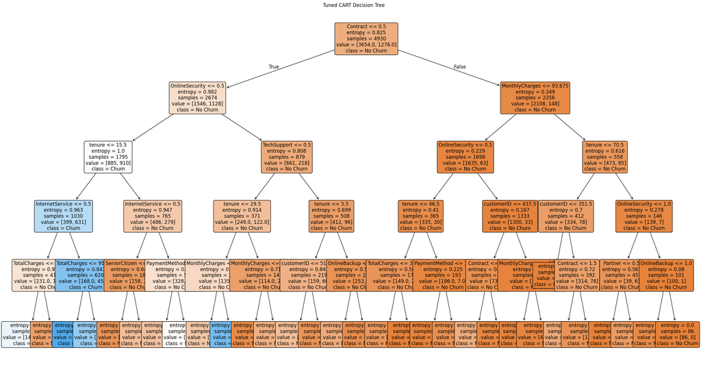

```python
# Visualizing the CART decision tree
plt.figure(figsize = (30,16))
plot_tree(tuned_clf, feature_names = all_predictors,
          class_names = ["No Churn", "Churn"],
          filled = True, rounded = True, fontsize = 12)
plt.title("Tuned CART Decision Tree")
plt.show()
```

While this tree gives us all the information we need about how the nodes are splitting and which features are being used, they can be dense and hard to read. Especially when we have max_depth = 5.

**dtreeviz**

One way to address this readability issue is to use dtreeviz. This tool generates interactive, high-resolution visualizations with enhanced clarity:

- It displays detailed node information, such as the distribution of class probabilities, number of samples, and impurity.
- It uses intuitive graphical elements (like pie charts and color gradients) to represent splits and node statistics.
- Fun Fact: dtreeviz was developed to make decision tree outputs more accessible and interpretable—it has been used in both academic and industry settings to effectively communicate model decisions.

For dtreeviz version 2.0 and later, the syntax is:

```python
!pip install --upgrade dtreeviz

import dtreeviz

X_train = X_train.fillna(0)
X_test = X_test.fillna(0)
print(X_train.isnull().sum())


# Now create the visualization using the new API:
m = dtreeviz.model(tuned_clf, X_train, y_train,
                   feature_names=all_predictors,
                   class_names=["No Churn", "Churn"])
m.view()
```

```
Downloading dtreeviz-2.2.2-py3-none-any.whl (91 kB)
   ━━━━━━━━━━━━━━━━━━━━━━━━━━━━━━━━━━━━━━━━ 91.8/91.8 kB 3.5 MB/s eta 0:00:00
customerID          0
gender              0
SeniorCitizen       0
Partner             0
Dependents          0
tenure              0
PhoneService        0
MultipleLines       0
InternetService     0
OnlineSecurity      0
OnlineBackup        0
DeviceProtection    0
TechSupport         0
StreamingTV         0
StreamingMovies     0
Contract            0
PaperlessBilling    0
PaymentMethod       0
MonthlyCharges      0
TotalCharges        0
dtype: int64
```

[output not shown]

[output cut: 1453 more lines]

[output not shown]

[figure not shown]

**Text-Based decision rules**

```python
tree_rules = export_text(tuned_clf, feature_names = all_predictors)
print("Decision Tree Rules:", tree_rules)
```

```
Decision Tree Rules: |--- Contract <= 0.50
|   |--- OnlineSecurity <= 0.50
|   |   |--- tenure <= 15.50
|   |   |   |--- InternetService <= 0.50
|   |   |   |   |--- TotalCharges <= 347.70
|   |   |   |   |   |--- class: 1
|   |   |   |   |--- TotalCharges >  347.70
|   |   |   |   |   |--- class: 0
|   |   |   |--- InternetService >  0.50
|   |   |   |   |--- TotalCharges <= 95.12
|   |   |   |   |   |--- class: 1
|   |   |   |   |--- TotalCharges >  95.12
|   |   |   |   |   |--- class: 1
|   |   |--- tenure >  15.50
|   |   |   |--- InternetService <= 0.50
|   |   |   |   |--- SeniorCitizen <= 0.50
|   |   |   |   |   |--- class: 0
|   |   |   |   |--- SeniorCitizen >  0.50
|   |   |   |   |   |--- class: 0
|   |   |   |--- InternetService >  0.50
|   |   |   |   |--- PaymentMethod <= 1.50
|   |   |   |   |   |--- class: 0
|   |   |   |   |--- PaymentMethod >  1.50
|   |   |   |   |   |--- class: 0
|   |--- OnlineSecurity >  0.50
|   |   |--- TechSupport <= 0.50
|   |   |   |--- tenure <= 29.50
|   |   |   |   |--- MonthlyCharges <= 94.03
|   |   |   |   |   |--- class: 0
|   |   |   |   |--- MonthlyCharges >  94.03
|   |   |   |   |   |--- class: 1
|   |   |   |--- tenure >  29.50
|   |   |   |   |--- MonthlyCharges <= 76.72
|   |   |   |   |   |--- class: 0
|   |   |   |   |--- MonthlyCharges >  76.72
|   |   |   |   |   |--- class: 0
|   |   |--- TechSupport >  0.50
|   |   |   |--- tenure <= 5.50
|   |   |   |   |--- customerID <= 5146.50
|   |   |   |   |   |--- class: 0
```

[output cut: 36 more lines]

```
|   |   |   |   |--- Contract <= 1.50
|   |   |   |   |   |--- class: 0
|   |   |   |   |--- Contract >  1.50
|   |   |   |   |   |--- class: 0
|   |   |--- tenure >  70.50
|   |   |   |--- OnlineSecurity <= 1.00
|   |   |   |   |--- Partner <= 0.50
|   |   |   |   |   |--- class: 0
|   |   |   |   |--- Partner >  0.50
|   |   |   |   |   |--- class: 0
|   |   |   |--- OnlineSecurity >  1.00
|   |   |   |   |--- OnlineBackup <= 1.00
|   |   |   |   |   |--- class: 0
|   |   |   |   |--- OnlineBackup >  1.00
|   |   |   |   |   |--- class: 0
```

**Let's take a look at the most important features.**

- **Importance of Feature Importances:** Feature importance scores quantify the contribution of each predictor to improving the model's performance (or capacity to reduce model's impurity). Basically, they tell you which features are most important in making predictions
- **How to interpret:** A high importance score indicates that a feature was frequently used for splits and significantly decreased impurity. A low score means the opposite, it was not used frequently and does not decrease impurity.

```
Feature: customerID, Importance: 0.0191
Feature: gender, Importance: 0.0000
Feature: SeniorCitizen, Importance: 0.0044
Feature: Partner, Importance: 0.0021
Feature: Dependents, Importance: 0.0000
Feature: tenure, Importance: 0.1033
Feature: PhoneService, Importance: 0.0000
Feature: MultipleLines, Importance: 0.0000
Feature: InternetService, Importance: 0.0793
Feature: OnlineSecurity, Importance: 0.1162
Feature: OnlineBackup, Importance: 0.0082
Feature: DeviceProtection, Importance: 0.0000
Feature: TechSupport, Importance: 0.0129
Feature: StreamingTV, Importance: 0.0000
Feature: StreamingMovies, Importance: 0.0000
Feature: Contract, Importance: 0.5342
Feature: PaperlessBilling, Importance: 0.0000
Feature: PaymentMethod, Importance: 0.0113
Feature: MonthlyCharges, Importance: 0.0648
Feature: TotalCharges, Importance: 0.0441
```

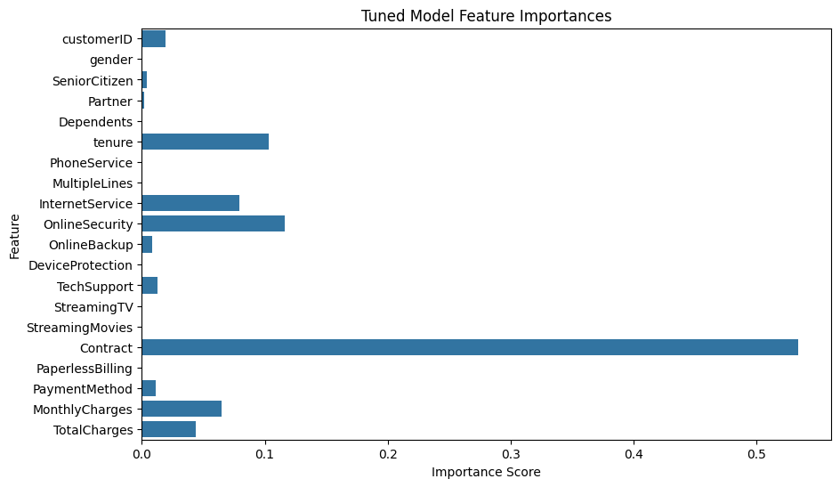

```python
# Displaying and plotting feature importances for the tuned model
importance = tuned_clf.feature_importances_
for feature, score in zip(all_predictors, importance):
  print(f"Feature: {feature}, Importance: {score:.4f}")

plt.figure(figsize = (10, 6))
sns.barplot(x = importance, y = all_predictors)
plt.title("Tuned Model Feature Importances")
plt.xlabel("Importance Score")
plt.ylabel("Feature")
plt.show()
```

## **Step 9: Interpreting and Communicating Results**

Interpreting and communicating results is a vital step for any data scientist—especially in a marketing setting—because it transforms technical model outcomes into actionable insights that drive business decisions. Here's what this step involves:

1. **Understanding the Model's Performance:**
   - **Evaluation Metrics:** Review metrics like accuracy, precision, recall, F1 score, and ROC AUC to understand how well the model distinguishes between classes (e.g., churn vs. no churn). For instance, a significant improvement in recall for churn means that more at-risk customers are correctly identified, which is crucial for retention strategies.
   - **Confusion Matrix:** Analyze the confusion matrix to see the distribution of true positives, true negatives, false positives, and false negatives. This helps pinpoint where the model might be misclassifying customers and where additional interventions might be necessary.
   - **Decision Rules and Feature Importances:** Use tools like export_text and feature importance charts to identify which factors are most influential. Knowing, for example, that tenure or monthly charges play a critical role in predicting churn can help shape targeted marketing campaigns.
2. **Translating Technical Insights into Marketing Actions:**
   - **Actionable Insights:** Explain in plain language what the model tells you. For example, if the tuned model shows that customers on month-to-month contracts with high monthly charges are more likely to churn, this insight can be used to develop targeted retention offers or adjust pricing strategies.
   - **Visualization for Clarity:** Leverage interactive and high-resolution visualizations (like dtreeviz) to present the decision tree. Visual aids help non-technical stakeholders quickly grasp the key decision rules and factors driving customer behavior.
   - **Storytelling:** Build a narrative around your findings. Summarize how specific features contribute to churn or retention, and connect these insights to potential marketing strategies. For example, "Our model indicates that customers with shorter tenure and higher monthly charges are at greater risk of churning, suggesting that early intervention with loyalty programs could be beneficial."
3. **Effective Communication:**
   - **Clear Reporting:** Prepare concise summary reports or dashboards that include both high-level metrics and detailed visualizations. This ensures that executives and marketing teams understand the performance and implications of the model.
   - **Tailoring to the Audience:** Adjust the level of technical detail based on your audience. For non-technical stakeholders, focus on the implications and recommendations rather than on the model's inner workings.
   - **Continuous Improvement:** Use the feedback from your communication to refine the model and analysis, ensuring that the insights remain relevant to the evolving marketing strategies.

By following these steps, you, as a data scientist, not only validate the performance of your CART decision tree model but also bridge the gap between data science and marketing. This ensures that technical results translate into actionable, strategic insights that can drive customer retention and overall business success.